# University of Tehran

## Homework 1

## Hesam Asadollahzadeh

### 810198346

# Libraries

```python
import numpy as np
import pandas as pd
from matplotlib import pyplot as plt
import seaborn as sns
from matplotlib.offsetbox import TextArea
```

```python
!pip install -q gdown
```

```python
!gdown -q 1oeaB--VhaHC7AfmmM0RpLgWtbO_tn-Hf
!unzip -q ML_HW1.zip
```

# Q1

$$P(\omega_1|x)=\frac{P(\omega_1)P(x|\omega_1)}{P(x)}$$$$P(\omega_2|x)=\frac{P(\omega_2)P(x|\omega_2)}{P(x)}$$$$P(x)=P(\omega_1)P(x|\omega_1)+P(\omega_2)P(x|\omega_2)$$$$P(\omega_1) = P(\omega_2) = 0.5$$$$P(x|\omega_i)= \frac{1}{\pi b}\frac{1}{1+(\frac{x-a_i}{b})^2}$$

```python
a1 = 3
a2 = 5
b = 1
```

```python
def cauchy_dist(x, a, b):
    return 1/((np.pi*b)*(1+((x-a)/b)**2))
```

```python
x = np.arange(-5, 10, 0.05)
P_x_given_w1 = cauchy_dist(x, a1, b)
P_x_given_w2 = cauchy_dist(x, a2, b)

P_w1_given_x = (0.5*P_x_given_w1)/(0.5*P_x_given_w1 + 0.5*P_x_given_w2)
P_w2_given_x = (0.5*P_x_given_w2)/(0.5*P_x_given_w1 + 0.5*P_x_given_w2)

expected_intersection = (a1+a2)/2
y_exp = (cauchy_dist(expected_intersection, a1, b)/2)/(cauchy_dist(expected_intersection, a1, b)/2 + cauchy_dist(expected_intersection, a2, b)/2)
```

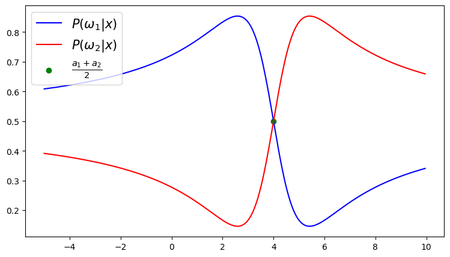

```python
plt.figure(figsize=(9, 5))
plt.plot(x, P_w1_given_x, color='blue', label='$P(\omega_1|x)$')
plt.plot(x, P_w2_given_x, color='red', label='$P(\omega_2|x)$')
plt.scatter(expected_intersection, y_exp,
            color='green', label=r'$\frac{a_1+a_2}{2}$')
plt.legend(loc='upper left', prop={'size': 15})
plt.show()
```

- Theoretically, we derived that $P(Error)$ is: $$P(Error) = \frac{1}{2}-\frac{1}{\pi}\tan^{-1}|\frac{a_2-a_1}{2b}|$$

```python
def error(x):
    return 1/2-(np.arctan(np.abs(x)))/np.pi
```

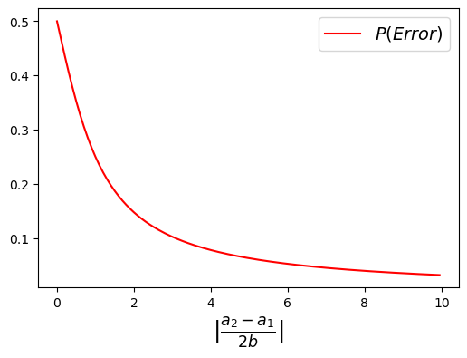

```python
x = np.arange(0, 10, 0.05)
plt.figure(figsize=(6, 4))
plt.plot(x, error(x), color='red', label='$P(Error)$')
plt.xlabel(r'$|\frac{a_2-a_1}{2b}$|', fontsize=18)
plt.legend(prop={'size': 14})
plt.show()
```

## Decision Boundary:

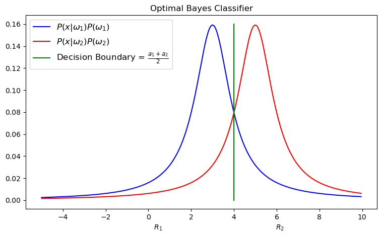

```python
x = np.arange(-5, 10, 0.05)
plt.figure(figsize=(9, 5))
plt.plot(x, (0.5*P_x_given_w1), color='blue', label='$P(x|\omega_1)P(\omega_1)$')
plt.plot(x, (0.5*P_x_given_w2), color='red', label='$P(x|\omega_2)P(\omega_2)$')
plt.plot([expected_intersection]*20, np.linspace(0, 0.16, 20), color='green', label=r'Decision Boundary = $\frac{a_1+a_2}{2}$')
plt.xlabel('\t\t$R_1$\t\t\t\t\t\t\t$R_2$')
plt.legend(loc='upper left', prop={'size': 12})
plt.title('Optimal Bayes Classifier')
plt.show()
```

## Minimum-Risk Classifier

```python
import math
```

```python
x = np.linspace(-6, 11, 400)
x_mrc1 = 2*a2-a1-math.sqrt(2*a2**2+2*a1**2-4*a1*a2-b**2)
x_mrc2 = 2*a2-a1+math.sqrt(2*a2**2+2*a1**2-4*a1*a2-b**2)
P_x_given_w1 = cauchy_dist(x, a1, b)
P_x_given_w2 = cauchy_dist(x, a2, b)
```

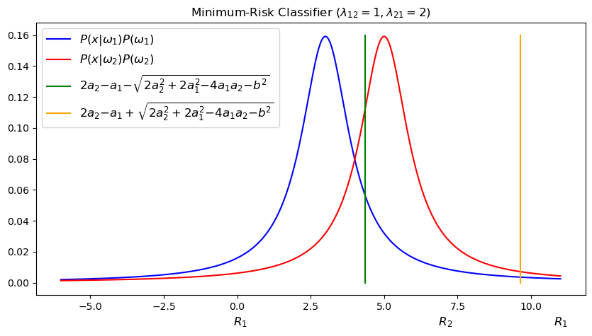

```python
plt.figure(figsize=(10, 5))
plt.plot(x, (0.5*P_x_given_w1), color='blue', label='$P(x|\omega_1)P(\omega_1)$')
plt.plot(x, (0.5*P_x_given_w2), color='red', label='$P(x|\omega_2)P(\omega_2)$')
plt.plot([x_mrc1]*20, np.linspace(0, 0.16, 20), color='green', label='$2a_2−a_1−\sqrt{2a_2^2 + 2a_1^2 − 4a_1a_2 − b^2}$')
plt.plot([x_mrc2]*20, np.linspace(0, 0.16, 20), color='orange', label='$2a_2−a_1+\sqrt{2a_2^2 + 2a_1^2 − 4a_1a_2 − b^2}$')
plt.xlabel('\t\t\t\t\t\t$R_1$\t\t\t\t\t\t\t$R_2$\t\t\t\t$R_1$', size=12, color='black')
plt.legend(loc='upper left', prop={'size': 12})
plt.title('Minimum-Risk Classifier ($\lambda_{12}=1, \lambda_{21}=2$)')
plt.show()
```

# Q3

```python
x_black = [-2, -1.5, -1.5, -1, -0.5, 0.5, 0.5, 1, 1.5, 1.5]
y_black = [-1, 0, 1, -1, 0.5, -0.5, 0.5, -1, -0.5, 0.5]
x_red = [0, 0.5, 1, 1, 1.5, 1.5, 2, 2, 2.5]
y_red = [0.5, 2, 1, 3, 0, 2, 1, 3, 2]
```

```python
x_black_mean = np.mean(x_black)
x_red_mean = np.mean(x_red)
y_black_mean = np.mean(y_black)
y_red_mean = np.mean(y_red)
(x_black_mean, y_black_mean), (x_red_mean, y_red_mean)
```

```
((-0.15, -0.15), (1.3333333333333333, 1.6111111111111112))
```

```python
red = np.array(list(zip(x_red, y_red))).T
cov_red = np.cov(red)
cov_red
```

```
array([[0.625     , 0.20833333],
       [0.20833333, 1.11111111]])
```

```python
black = np.array(list(zip(x_black, y_black))).T
cov_black = np.cov(black)
cov_black
```

```
array([[1.725     , 0.00277778],
       [0.00277778, 0.55833333]])
```

```python
W_red = -1/2*np.linalg.inv(cov_red)
W_red
```

```
array([[-0.85333333,  0.16      ],
       [ 0.16      , -0.48      ]])
```

```python
W_black = -1/2*np.linalg.inv(cov_black)
W_black
```

```
array([[-0.28985739,  0.00144208],
       [ 0.00144208, -0.89552956]])
```

```python
w_red = np.linalg.inv(cov_red)@np.array([[x_red_mean], [y_red_mean]])
w_red
```

```
array([[1.76],
       [1.12]])
```

```python
w_black = np.linalg.inv(cov_black)@np.array([[x_black_mean], [y_black_mean]])
w_black
```

```
array([[-0.0865246 ],
       [-0.26822625]])
```

```python
range_x1 = np.arange(-5, 3.5, 0.01)
x2_1 = lambda x1: (-32*x1-139-np.sqrt(10432*(x1**2)-22184*x1+45361))/84
x2_2 = lambda x1: (-32*x1-139+np.sqrt(10432*(x1**2)-22184*x1+45361))/84
range_x2_1 = x2_1(range_x1)
range_x2_2 = x2_2(range_x1)
```

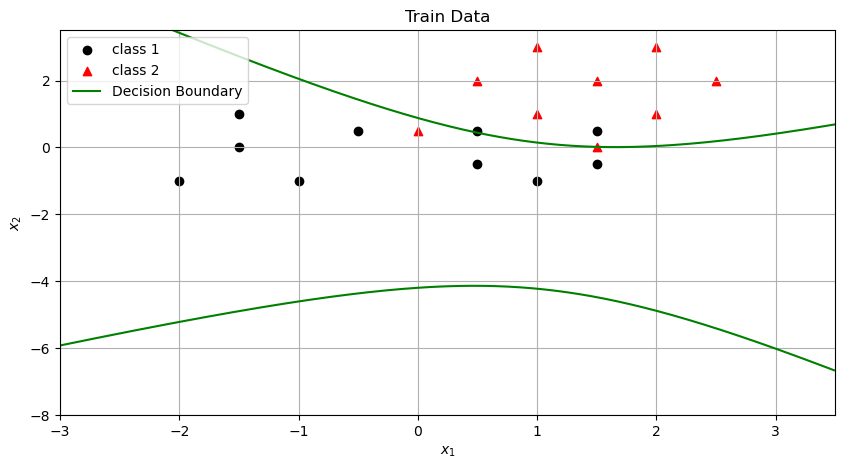

```python
plt.figure(figsize=(10, 5))
plt.scatter(x_black, y_black, color='black', marker='o', label='class 1')
plt.scatter(x_red, y_red, color='red', marker='^', label='class 2')
plt.plot(range_x1, range_x2_1, color='green', label='Decision Boundary')
plt.plot(range_x1, range_x2_2, color='green')
plt.xlim(-3, 3.5)
plt.ylim(-8, 3.5)
plt.xlabel('$x_1$')
plt.ylabel('$x_2$')
plt.title('Train Data')
plt.legend(loc='upper left')
plt.grid()
plt.show()
```

```python
x2_1 = lambda x1: (-32*x1-139-np.sqrt(10432*(x1**2)-22184*x1+33769))/84
x2_2 = lambda x1: (-32*x1-139+np.sqrt(10432*(x1**2)-22184*x1+33769))/84
range_x2_1 = x2_1(range_x1)
range_x2_2 = x2_2(range_x1)
```

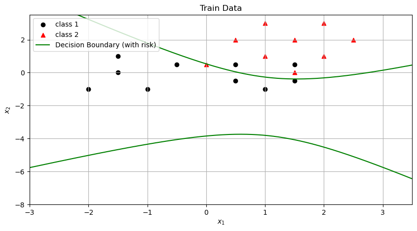

```python
plt.figure(figsize=(10, 5))
plt.scatter(x_black, y_black, color='black', marker='o', label='class 1')
plt.scatter(x_red, y_red, color='red', marker='^', label='class 2')
plt.plot(range_x1, range_x2_1, color='green', label='Decision Boundary (with risk)')
plt.plot(range_x1, range_x2_2, color='green')
plt.xlim(-3, 3.5)
plt.ylim(-8, 3.5)
plt.xlabel('$x_1$')
plt.ylabel('$x_2$')
plt.title('Train Data')
plt.legend(loc='upper left')
plt.grid()
plt.show()
```

# Q5

```python
df = pd.read_csv('Data/penguins.csv', na_values='x')
df.head()
```

|  | species | culmen_length_mm | culmen_depth_mm | flipper_length_mm | body_mass_g |
| --- | --- | --- | --- | --- | --- |
| 0 | Adelie | 39.1 | 18.7 | 181.0 | 3750.0 |
| 1 | Adelie | 39.5 | 17.4 | 186.0 | 3800.0 |
| 2 | Adelie | 40.3 | 18.0 | 195.0 | 3250.0 |
| 3 | Adelie | NaN | NaN | NaN | NaN |
| 4 | Adelie | 36.7 | 19.3 | 193.0 | 3450.0 |

```python
df.info()
```

```
<class 'pandas.core.frame.DataFrame'>
RangeIndex: 343 entries, 0 to 342
Data columns (total 5 columns):
 #   Column             Non-Null Count  Dtype
---  ------             --------------  -----
 0   species            343 non-null    object
 1   culmen_length_mm   337 non-null    float64
 2   culmen_depth_mm    337 non-null    float64
 3   flipper_length_mm  337 non-null    float64
 4   body_mass_g        337 non-null    float64
dtypes: float64(4), object(1)
memory usage: 13.5+ KB
```

```python
len(df)
```

```
343
```

```python
df.isna().sum()
```

```
species              0
culmen_length_mm     6
culmen_depth_mm      6
flipper_length_mm    6
body_mass_g          6
dtype: int64
```

```python
df.species.value_counts()
```

```
Adelie       152
Gentoo       123
Chinstrap     68
Name: species, dtype: int64
```

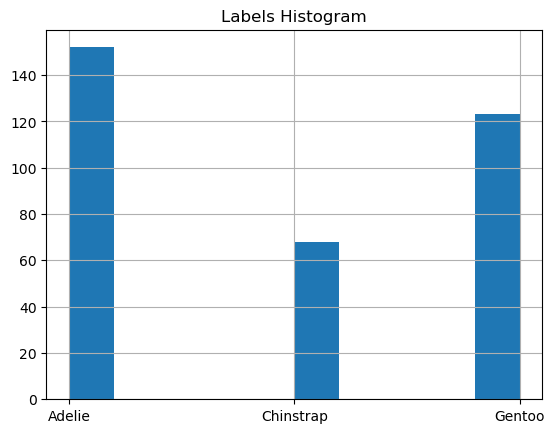

```python
df['species'].hist()
plt.title('Labels Histogram')
plt.show()
```

```python
df.describe()
```

|  | culmen_length_mm | culmen_depth_mm | flipper_length_mm | body_mass_g |
| --- | --- | --- | --- | --- |
| count | 337.000000 | 337.000000 | 337.000000 | 337.000000 |
| mean | 43.883680 | 17.163798 | 200.804154 | 4195.252226 |
| std | 5.474829 | 1.974991 | 14.028359 | 800.783013 |
| min | 32.100000 | 13.100000 | 172.000000 | 2700.000000 |
| 25% | 39.200000 | 15.600000 | 190.000000 | 3550.000000 |
| 50% | 44.100000 | 17.300000 | 197.000000 | 4000.000000 |
| 75% | 48.500000 | 18.700000 | 213.000000 | 4750.000000 |
| max | 59.600000 | 21.500000 | 231.000000 | 6300.000000 |

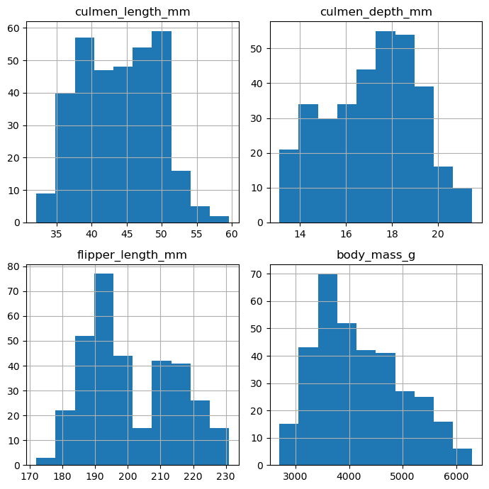

```python
df.hist(figsize=(7, 7))
plt.tight_layout()
plt.show()
```

```python
df = df.fillna(df.quantile(0.5))
```

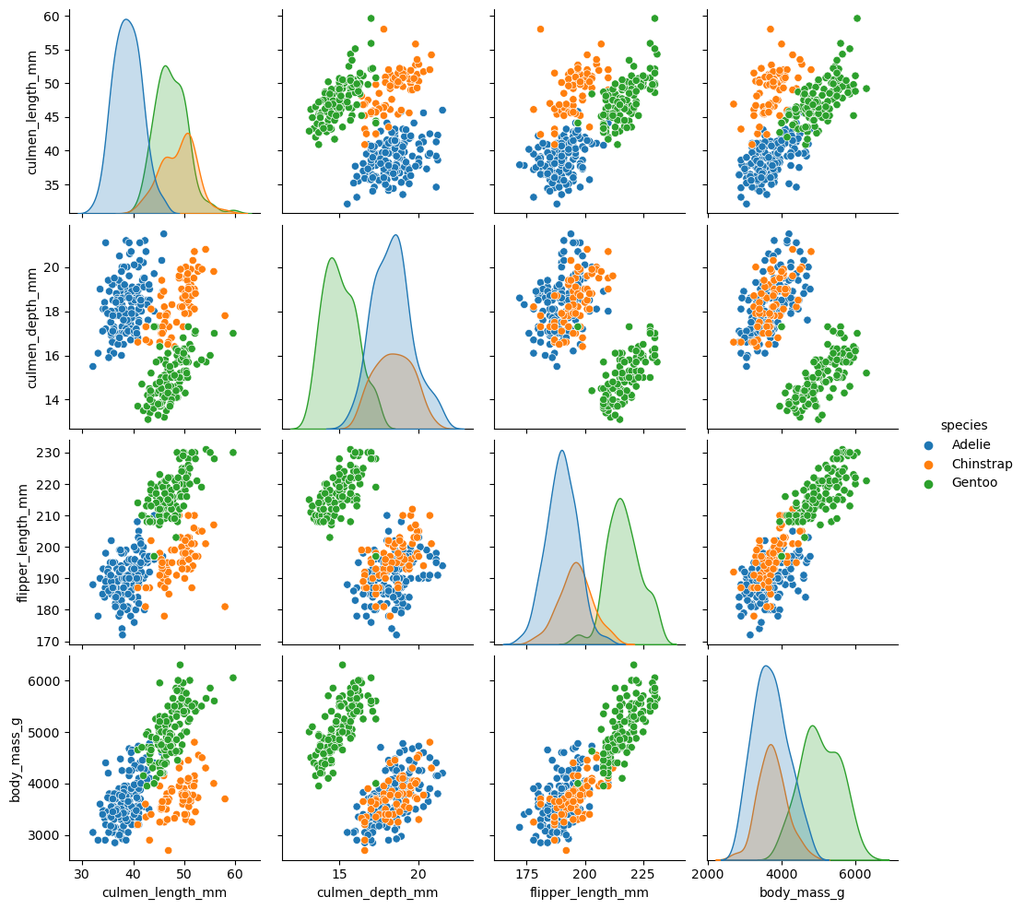

```python
sns.pairplot(df, hue='species')
plt.show()
```

### Naive Bayes and Optimal Bayes Classifier:

Bayes Rule : $$ P(Y = i|x) = \frac{P(x|Y=i) * P(Y=i)}{P(x)} \qquad \forall i$$

#### When likelihood distribution is not known:

##### Optimal Bayes classifier:

Optimal bayes classifier chooses the class that has greatest posteriori probability of occurrence. To calculate posterior probability we can use the given formula ($I(x_{i}=x \land y_{i}=y)=1$ if $x_{i}=x$ and $y_{i}=y$ and 0 otherwise.): $$ p(y|x) = \frac{p(y,x)}{p(x)} = \frac{\sum_{i=1}^{n}I(x_{i}=x \land y_{i}=y)}{\sum_{i=1}^{n}I(x_{i}=x)} \qquad,\quad $$

- Optimal bayes classifier has high computational cost. For example if there are k classes, for classifying a new data point x with d features and n different possible values per each feature, we have to compute $k(n^d-1)$ parameters.
- Optimal bayes classifier is only useful whene there are many training vectors with the same identical features as x. But in high dimensional spaces or with continuous x, as p(y,x) and p(x) converge to zero it is not possible to use optimal bayes classifier.

##### Naive Bayes classifier:

The Naive Bayes classifier approximates the optimal Bayes classifier by looking at the empirical distribution and by assuming independence of predictors. Naive Bayes assumes feature values are independent given the label, thus: $$p(x|y) = \prod_{j=1}^{d}p(x_{j}|y)\quad for \quad x=(x_{1},...,x_{d}) $$

##### When likelihood distribution is known:

When likelihood is known the posterior probability can be directly calculated by multiplying the prior and likelihood.

### Bayes Classfier

```python
class BayesClassifier():
    def __init__(self, target_col):
        self.priors = {}
        self.target_col = target_col
        self.attributes_dict = {}

    def mean(self, values):
        return sum(values)/float(len(values))

    def stdev(self, values):
        avg = self.mean(values)
        variance = sum([((x-avg)**2) for x in values])/len(values)
        return variance**0.5

    def univariate_gaussian_probability(self, x, avg, std):
        return (1/(math.sqrt(2*math.pi)*std)) * math.exp(-(math.pow(x-avg, 2)/(2*math.pow(std, 2))))

    def multivariate_gaussian_probability(self,x, mean_vec, cov_mat):
        x = np.atleast_2d(x).T
        cov_det, cov_inv = np.linalg.det(cov_mat), np.linalg.inv(cov_mat)
        temp = np.exp(-.5 * (x - mean_vec).T @ cov_inv @ (x - mean_vec))
        return (2 * np.pi) ** (-x.size/2) * cov_det ** (-1/2) * temp


    def train(self, X_train, Y_train, oneVsAllLabel):
        total_data_count = len(X_train)
        train_df = pd.DataFrame(X_train)
        train_df[self.target_col] = list(Y_train)
        df1, df2 = train_df[(mask:=train_df[self.target_col] == oneVsAllLabel)], train_df[~mask]
        train_dfs = [df1, df2]
        labels = [True, False]
        for label, df in zip(labels, train_dfs):
            self.attributes_dict[label] = self.get_distribution_statistics(df)
            self.priors[label] = len(df)/total_data_count


    def predict(self, x_test):
        test_df = pd.DataFrame(x_test)
        predictions = []
        for i in range(len(test_df)):
            prediction_dict = self.calculate_class_probabilities(test_df.iloc[i])
            predictions.append(max(prediction_dict, key=prediction_dict.get))
        return predictions
```

#### Gaussian Optimal Bayes Classifier

```python
class GaussianOptimalBayesClassifier(BayesClassifier):
    def __init__(self, target_col):
        super().__init__(target_col)

    def get_distribution_statistics(self,dataset):
        """
            returns mean vector and covariance matrix of each class
        """
        feature_cols = list(dataset.columns)[:-1]
        mean_vector = [self.mean(dataset[column]) for column in feature_cols]
        mean_vector = np.atleast_2d(mean_vector).T
        cov_matrix = np.cov(np.array([dataset[column] for column in feature_cols]), bias=True)
        cov_matrix = np.atleast_2d(cov_matrix)
        return [mean_vector, cov_matrix]

    def calculate_class_probabilities(self,test_row):
        probabilities = {}
        for classValue in self.attributes_dict.keys():
            probabilities[classValue] = self.priors[classValue]
            mean_vec, cov_mat = self.attributes_dict[classValue][0], self.attributes_dict[classValue][1]
            probabilities[classValue] *= self.multivariate_gaussian_probability(test_row, mean_vec, cov_mat)
        return probabilities
```

#### Gaussian Naive Bayes Classifier

All features are considered independent. Also, it is assumed that continuous values associated with each feature are distributed according to a normal distribution.

```python
class GaussianNBClassifier(BayesClassifier):

    def __init__(self, target_col):
        super().__init__(target_col)

    def get_distribution_statistics(self, dataset):
        """
            return each feature's mean and std
        """
        feature_cols = list(dataset.columns)[:-1]
        feature_atts = [(self.mean(dataset[column]), self.stdev(dataset[column])) for column in feature_cols]
        return feature_atts

    def calculate_class_probabilities(self, test_row):
        probabilities = {}
        for classValue in self.attributes_dict.keys():
            probabilities[classValue] = self.priors[classValue]
            for i in range(len(self.attributes_dict[classValue])):
                avg, std_dev = self.attributes_dict[classValue][i][0], self.attributes_dict[classValue][i][1]
                probabilities[classValue] *= self.univariate_gaussian_probability(test_row[i], avg, std_dev)
        return probabilities
```

##### Splitting Data

```python
import random
def stratified_train_test_split(df, target_col, oneVsAllLabel, test_size=0.2, seed=76):
        random.seed(seed)
        label1_inds = df.index[df[target_col] == oneVsAllLabel].tolist()
        label0_inds = df.index[df[target_col] != oneVsAllLabel].tolist()
        train_label1_inds = random.sample( label1_inds, int((1-test_size)*len(label1_inds))+1)
        train_label0_inds = random.sample( label0_inds, int((1-test_size)*len(label0_inds)))

        test_label1_inds = [i for i in label1_inds if i not in train_label1_inds]
        test_label0_inds = [i for i in label0_inds if i not in train_label0_inds]

        X_train = np.array(df.iloc[:,1:].loc[train_label1_inds+train_label0_inds])
        Y_train = np.array(df.iloc[:,0].loc[train_label1_inds+train_label0_inds])
        x_test = np.array(df.iloc[:,1:].loc[test_label1_inds+test_label0_inds])
        y_test = np.array(df.iloc[:,0].loc[test_label1_inds+test_label0_inds])
        return X_train, Y_train, x_test, y_test
```

##### Evaluating Model

```python
def get_metrics(y_true, predictions, pos_label):
    TP = sum([1 for i in range(len(y_true)) if y_true[i] == predictions[i] and  predictions[i]==pos_label])
    TN = sum([1 for i in range(len(y_true)) if y_true[i] == predictions[i] and  predictions[i]!=pos_label])
    FP = sum([1 for i in range(len(y_true)) if y_true[i] != predictions[i] and  predictions[i]==pos_label])
    FN = sum([1 for i in range(len(y_true)) if y_true[i] != predictions[i] and  predictions[i]!=pos_label])
    return TP, TN, FP, FN

def evaluate_model(y_true, y_pred, oneVsAllLabel):
        TP, TN, FP, FN =  get_metrics(y_true, y_pred, pos_label=oneVsAllLabel)
        print('Recall: %.3f' % (TP / (FN + TP)))
        print('Precision: %.3f' % (TP / (FP + TP)))
        print('Accuracy: %.3f' % ((TP + TN)/ (TP + FN + TN + FP)))


def plot_confusion_matrix(y_true, y_pred, oneVsAllLabel):
    TP, TN, FP, FN =  get_metrics(y_true, y_pred, oneVsAllLabel)
    confusion_mat = np.array([[TP,FN], [FP,TN]])
    group_names = ['True Pos','False Neg','False Pos','True Neg']
    group_counts = ["{0:0.0f}".format(value) for value in
                    confusion_mat.flatten()]

    labels = [f"{v1}\n{v2}" for v1, v2 in
                zip(group_names,group_counts)]

    labels = np.asarray(labels).reshape(2,2)

    ax = sns.heatmap(confusion_mat, annot=labels, fmt='', cmap='Blues')

    ax.set_title('Confusion Matrix\n\n');
    ax.set_xlabel('\nPredicted Values')
    ax.set_ylabel('Actual Values ');
    ax.xaxis.set_ticklabels(['True','False'])
    ax.yaxis.set_ticklabels(['True','False'])
    plt.show()
```

#### Results:

##### Naive Bayes Classifier

```
Recall: 0.933
Precision: 0.903
Accuracy: 0.928
```

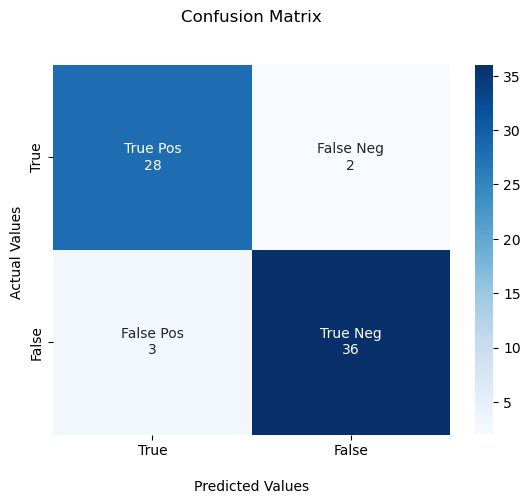

```python
model = GaussianNBClassifier('species')
x_train, y_train, x_test, y_test = stratified_train_test_split(df, target_col='species', oneVsAllLabel='Adelie', test_size=0.2)
model.train(x_train, y_train, 'Adelie')
predictions = model.predict(x_test)
evaluate_model(y_test=='Adelie', predictions, True)
plot_confusion_matrix(y_test=='Adelie', predictions, True)
```

```
Recall: 1.000
Precision: 1.000
Accuracy: 1.000
```

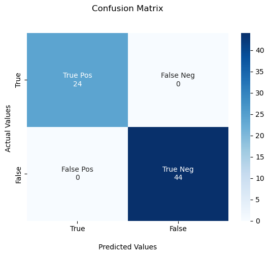

```python
model = GaussianNBClassifier('species')
x_train, y_train, x_test, y_test = stratified_train_test_split(df, target_col='species', oneVsAllLabel='Gentoo', test_size=0.2)
model.train(x_train, y_train, 'Gentoo')
predictions = model.predict(x_test)
evaluate_model(y_test=='Gentoo', predictions, True)
plot_confusion_matrix(y_test=='Gentoo', predictions, True)
```

```
Recall: 0.769
Precision: 1.000
Accuracy: 0.956
```

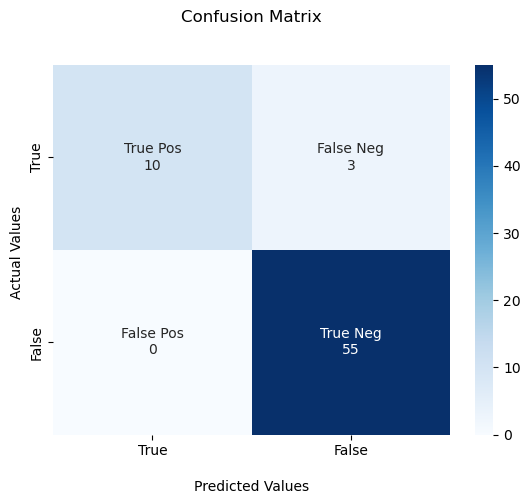

```python
model = GaussianNBClassifier('species')
x_train, y_train, x_test, y_test = stratified_train_test_split(df, target_col='species', oneVsAllLabel='Chinstrap', test_size=0.2)
model.train(x_train, y_train, 'Chinstrap')
predictions = model.predict(x_test)
evaluate_model(y_test=='Chinstrap', predictions, True)
plot_confusion_matrix(y_test=='Chinstrap', predictions, True)
```

### Using Scikit-Learn:

```python
from sklearn.naive_bayes import GaussianNB
from sklearn.model_selection import train_test_split
from sklearn.metrics import accuracy_score, classification_report
from sklearn.metrics import confusion_matrix, plot_confusion_matrix

# Split the dataset into training and testing sets
X_train, X_test, y_train, y_test = train_test_split(df[list(set(df.columns)-set(['species']))], df[['species']], test_size=0.2, random_state=42)

# Train the model
gnb_1 = GaussianNB()
y_test_1 = np.where(y_test == 'Adelie', True, False).reshape(-1)
gnb_1.fit(X_train, np.array((y_train=='Adelie')).reshape(-1))

gnb_2 = GaussianNB()
y_test_2 = np.where(y_test == 'Gentoo', True, False).reshape(-1)
gnb_2.fit(X_train, np.array((y_train=='Gentoo')).reshape(-1))

gnb_3 = GaussianNB()
y_test_3 = np.where(y_test == 'Chinstrap', True, False).reshape(-1)
gnb_3.fit(X_train, np.array((y_train=='Chinstrap')).reshape(-1))

y_pred_1 = gnb_1.predict(X_test)
y_pred_2 = gnb_2.predict(X_test)
y_pred_3 = gnb_3.predict(X_test)
```

```
Adelie vs. All
Accuracy: 0.9130434782608695
Classification Report:
               precision    recall  f1-score   support

       False       0.89      0.94      0.91        34
        True       0.94      0.89      0.91        35

    accuracy                           0.91        69
   macro avg       0.91      0.91      0.91        69
weighted avg       0.91      0.91      0.91        69
```

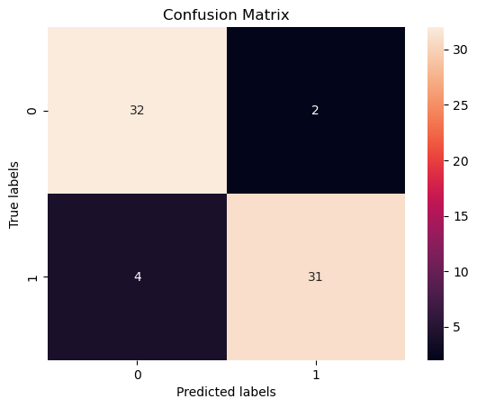

```python
print('Adelie vs. All')
accuracy = accuracy_score(y_test_1, y_pred_1)
report = classification_report(y_test_1, y_pred_1)

print("Accuracy:", accuracy)
print("Classification Report:\n", report)
cm = confusion_matrix(y_test_1, y_pred_1)
sns.heatmap(cm, annot=True, fmt='d')
plt.xlabel('Predicted labels')
plt.ylabel('True labels')
plt.title('Confusion Matrix')
plt.show()
```

```
Gentoo vs. All
Accuracy: 0.9855072463768116
Classification Report:
               precision    recall  f1-score   support

       False       0.98      1.00      0.99        47
        True       1.00      0.95      0.98        22

    accuracy                           0.99        69
   macro avg       0.99      0.98      0.98        69
weighted avg       0.99      0.99      0.99        69
```

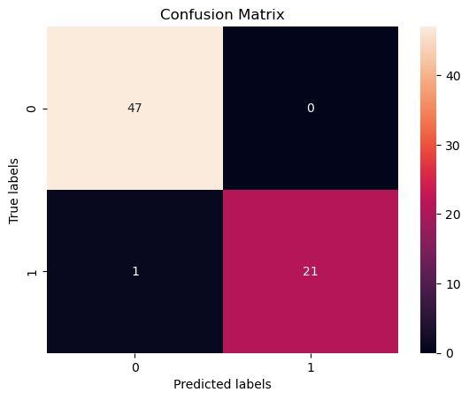

```python
print('Gentoo vs. All')
accuracy = accuracy_score(y_test_2, y_pred_2)
report = classification_report(y_test_2, y_pred_2)

print("Accuracy:", accuracy)
print("Classification Report:\n", report)
cm = confusion_matrix(y_test_2, y_pred_2)
sns.heatmap(cm, annot=True, fmt='d')
plt.xlabel('Predicted labels')
plt.ylabel('True labels')
plt.title('Confusion Matrix')
plt.show()
```

```
Chinstrap vs. All
Accuracy: 0.9420289855072463
Classification Report:
               precision    recall  f1-score   support

       False       0.95      0.98      0.97        57
        True       0.90      0.75      0.82        12

    accuracy                           0.94        69
   macro avg       0.92      0.87      0.89        69
weighted avg       0.94      0.94      0.94        69
```

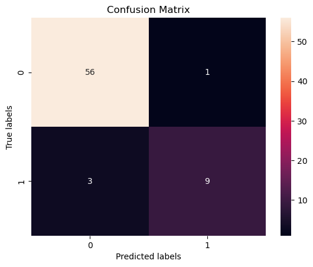

```python
print('Chinstrap vs. All')
accuracy = accuracy_score(y_test_3, y_pred_3)
report = classification_report(y_test_3, y_pred_3)

print("Accuracy:", accuracy)
print("Classification Report:\n", report)
cm = confusion_matrix(y_test_3, y_pred_3)
sns.heatmap(cm, annot=True, fmt='d')
plt.xlabel('Predicted labels')
plt.ylabel('True labels')
plt.title('Confusion Matrix')
plt.show()
```

# Q6

```python
from numpy import asarray
import os
from PIL import Image
import random
from matplotlib import pyplot as plt

def load_data(data_dir):
    images = []
    labels = []
    for filename in os.listdir(data_dir):
        image = Image.open(os.path.join(data_dir,filename))
        images.append(asarray(image))
        labels.append(filename[0])
    return images,labels
```

```python
data_dir = './Data/image'
images, labels = load_data(data_dir)
```

```python
label_map = {'j':1 , 's':0}
Rlabel_map = {1:'j', 0:'s'}
labels = [label_map[label] for label in labels]
```

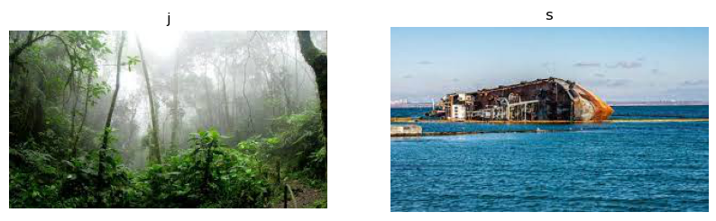

```python
label1_ind = random.choice([i for i, x in enumerate(labels) if x == 1])
label0_ind = random.choice([i for i, x in enumerate(labels) if x == 0])

fig = plt.figure(figsize=(10, 7))
fig.add_subplot(1, 2, 1)
plt.imshow(images[label1_ind])
plt.axis('off')
plt.title(Rlabel_map[1])
fig.add_subplot(1, 2, 2)
plt.imshow(images[label0_ind])
plt.axis('off')
plt.title(Rlabel_map[0])
plt.show()
```

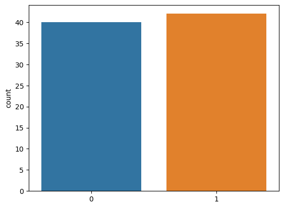

```python
sns.countplot(x=labels,)
plt.show()
```

```python
df = pd.DataFrame()
df['R_mean'] = [(np.sum(img[:,:,0])/(img.shape[0]*img.shape[1])) for img in images]
df['G_mean'] = [(np.sum(img[:,:,1])/(img.shape[0]*img.shape[1])) for img in images]
df['B_mean'] = [(np.sum(img[:,:,2])/(img.shape[0]*img.shape[1])) for img in images]
df['label'] = labels
```

```python
df['label'].value_counts()
```

```
1    42
0    40
Name: label, dtype: int64
```

```python
df.describe()
```

|  | R_mean | G_mean | B_mean | label |
| --- | --- | --- | --- | --- |
| count | 82.000000 | 82.000000 | 82.000000 | 82.000000 |
| mean | 92.318159 | 111.220557 | 109.101517 | 0.512195 |
| std | 34.214232 | 31.849347 | 60.793683 | 0.502927 |
| min | 25.536760 | 37.877679 | 14.222679 | 0.000000 |
| 25% | 69.970372 | 90.155213 | 54.200506 | 0.000000 |
| 50% | 94.490074 | 106.193748 | 101.222620 | 1.000000 |
| 75% | 118.784064 | 140.070604 | 165.512870 | 1.000000 |
| max | 173.952033 | 183.902534 | 244.137804 | 1.000000 |

```python
df.groupby(["label"]).agg([np.mean])
```

| label | R_mean mean | G_mean mean | B_mean mean |
| --- | --- | --- | --- |
| 0 | 91.457225 | 129.986866 | 160.578820 |
| 1 | 93.138096 | 93.347883 | 60.075514 |

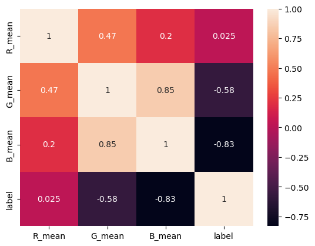

```python
corr = df.corr()
sns.heatmap(corr,annot=True)
plt.show()
```

[figure not shown]

```python
fig = plt.figure(figsize=(8, 8))
axes = fig.add_subplot(projection='3d')

axes.plot(df[df['label']==1]["R_mean"],df[df['label']==1]["G_mean"],df[df['label']==1]["B_mean"],'.',label="Sea",color='blue')
axes.plot(df[df['label']==0]["R_mean"],df[df['label']==0]["G_mean"],df[df['label']==0]["B_mean"],'.',label="Jungle",color='green')
axes.set_xlabel('R mean')
axes.set_ylabel('G mean')
axes.set_zlabel('B mean')
plt.xlim(0,200)
plt.ylim(0,250)
plt.legend(loc="upper left")
plt.show()
```

## Classification model

we want to classify any image as being green or blue in overall color. First we calculate per-channel image mean for each image. Then for each image we compare its green channel mean with blue channel mean. If green channel mean is greater we classify image as Jungle and Sea otherwise.

```python
def predict(images):
    gChannel = [(np.sum(img[:,:,1])/(img.shape[0]*img.shape[1])) for img in images]
    bChannel = [(np.sum(img[:,:,2])/(img.shape[0]*img.shape[1])) for img in images]
    predictions = [1 if gChannel[i]>bChannel[i] else 0 for i in range(0,len(gChannel))]
    return predictions
```

```python
from sklearn.metrics import classification_report

y_pred = predict(images)
print(classification_report(labels, y_pred, target_names=['Sea', 'Jungle']))
```

```
              precision    recall  f1-score   support

         Sea       0.95      0.97      0.96        40
      Jungle       0.98      0.95      0.96        42

    accuracy                           0.96        82
   macro avg       0.96      0.96      0.96        82
weighted avg       0.96      0.96      0.96        82
```

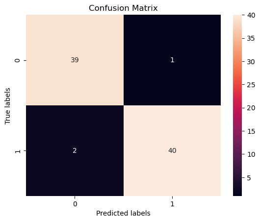

```python
from sklearn.metrics import confusion_matrix
import seaborn as sns

cm = confusion_matrix(labels, y_pred)
sns.heatmap(cm, annot=True)
plt.xlabel('Predicted labels')
plt.ylabel('True labels')
plt.title('Confusion Matrix')
plt.show()
```

```python
def print_missclassified_samples(images,y_true,y_pred):

    FN_ind = random.choice([i for i in range(len(y_true)) if y_true[i] == 1 and y_pred[i]==0 ])
    FP_ind = random.choice([i for i in range(len(y_true)) if y_true[i] == 0 and y_pred[i]==1 ])
    reverse_labelMap = dict(map(reversed, label_map.items()))
    title1='True label:'+str(Rlabel_map[y_true[FN_ind]])+',   Predicted label:'+str(Rlabel_map[y_pred[FN_ind]])
    title2='True label:'+str(Rlabel_map[y_true[FP_ind]])+',   Predicted label:'+str(Rlabel_map[y_pred[FP_ind]])

    fig = plt.figure(figsize=(10, 7))
    fig.add_subplot(2, 1, 1)
    plt.imshow(images[FN_ind])
    plt.axis('off')

    plt.title(title1)

    fig.add_subplot(2, 1, 2)
    plt.imshow(images[FP_ind])
    plt.axis('off')
    plt.title(title2)
```

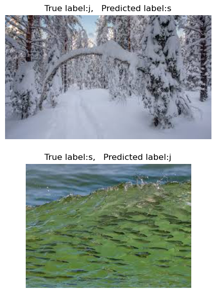

```python
print_missclassified_samples(images,labels,y_pred)
```

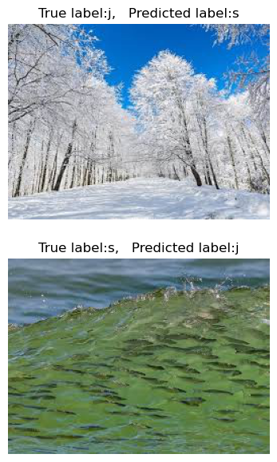

```python
print_missclassified_samples(images,labels,y_pred)
```